# Case_Study: Cyclistic Study

Lim Dao Yuan

2022-09-26

# **Case Study: How Does a Bike-Share Navigate Speedy Success?**

## **Task Details**

### **Scenario**

You are a junior data analyst working in the marketing analyst team at Cyclistic, a bike-share company in Chicago. The director of marketing believes the company’s future success depends on maximizing the number of annual memberships. Therefore, your team wants to understand how casual riders and annual members use Cyclistic bikes differently. From these insights, your team will design a new marketing strategy to convert casual riders into annual members. But first, Cyclistic executives must approve your recommendations, so they must be backed up with compelling data insights and professional data visualizations.

### **About The Company**

In 2016, Cyclistic launched a successful bike-share offering. Since then, the program has grown to a fleet of 5,824 bicycles that are geotracked and locked into a network of 692 stations across Chicago. The bikes can be unlocked from one station and returned to any other station in the system anytime. Until now, Cyclistic’s marketing strategy relied on building general awareness and appealing to broad consumer segments.

One approach that helped make these things possible was the flexibility of its pricing plans: single-ride passes, full-day passes, and annual memberships. Customers who purchase single-ride or full-day passes are referred to as casual riders. Customers who purchase annual memberships are Cyclistic members. Cyclistic’s finance analysts have concluded that annual members are much more profitable than casual riders. Although the pricing flexibility helps Cyclistic attract more customers, Moreno believes that maximizing the number of annual members will be key to future growth.

Rather than creating a marketing campaign that targets all-new customers, Moreno believes there is a very good chance to convert casual riders into members. She notes that casual riders are already aware of the Cyclistic program and have chosen Cyclistic for their mobility needs.

Moreno has set a clear goal: Design marketing strategies aimed at converting casual riders into annual members. In order to do that, however, the marketing analyst team needs to better understand how annual members and casual riders differ, why casual riders would buy a membership, and how digital media could affect their marketing tactics. Moreno and her team are interested in analyzing the Cyclistic historical bike trip data to identify trends.

### **Pricing**

| Passes | Price |
| --- | --- |
| Single-Ride Pass | $1 + $0.16 / minute |
| Full-Day Pass | $15 + $0.16 / minute after 3 hours |
| Annual Memberships | $119 annually + $0.16 / minute after 45 minutes per day |
| E-Bike | $1 + $0.39 / minute or $0.16 / minute for members |

### Riding Areas

[figure not shown]

### **Business Task**

Identify the distinctive behavior between casual riders and annual members.

### **Expected Outcome**

At the end of this report, the analyzed information is expected to assist the company to achieve their goal, and that is to convert potential users, casual riders into annual members and consequently increasing the profitability from the already existing pricing plans.

### **Involved Stakeholders**

- **Cyclistic**: A bike-share program that features more than 5,800 bicycles and 600 docking stations. Cyclistic sets itself apart by also offering reclining bikes, hand tricycles, and cargo bikes, making bike-share more inclusive to people with disabilities and riders who can’t use a standard two-wheeled bike. The majority of riders opt for traditional bikes; about 8% of riders use the assistive options. Cyclistic users are more likely to ride for leisure, but about 30% use them to commute to work each day.
- **Lily Moreno**: The director of marketing and your manager. Moreno is responsible for the development of campaigns and initiatives to promote the bike-share program. These may include email, social media, and other channels.
- **Cyclistic marketing analytics team**: A team of data analysts who are responsible for collecting, analyzing, and reporting data that helps guide Cyclistic marketing strategy. You joined this team six months ago and have been busy learning about Cyclistic’s mission and business goals — as well as how you, as a junior data analyst, can help Cyclistic achieve them.
- **Cyclistic executive team**: The notoriously detail-oriented executive team will decide whether to approve the recommended marketing program.

## **Data Description**

### **Clarification**

The datasets used in this case study are obtained from the DIVVY bicycle sharing service that is located in Chicago, United States. It was made available by Motivate International Inc. under this [license](https://ride.divvybikes.com/data-license-agreement). The datasets has a different name since Cyclistic is a fictional company. The datasets can be downloaded from [this link](https://divvy-tripdata.s3.amazonaws.com/index.html).

In this case study, the previous 12 months of trip data will be used which is from September 2021 until August 2022. Based on the ROCCC concept, which are reliable, original, comprehensive, current and cited, the datasets are considered unbias and has a good credibility. There is no standard station ID format but it does not bring any significant impact to this case study.

- **Reliable** - The source of the datasets are collected by DIVVY bicycle sharing service, the location data can be plotted on the map using Tableau / Power BI.
- **Original** - The datasets are collected by DIVVY bicycle sharing service, an existing company and it is considered as a first-party data source.
- **Comprehensive** - The datasets has the right data for the business task.
- **Current** - The datasets are from recent dates (September 2021 until August 2022).
- **Cited** - The datasets are from DIVVY bicycle sharing service’s official website with provided license.

## **Data Cleaning Process**

The tools that are used during the data cleaning process are RStudio to produce a R markdown report and to remove any unnecessary data such as duplicate data and null data while Excel and Tableau are used for the purpose of data visualization.

### **Importing Data**

The following codes are used to import the 12 months of data from the spreadsheets into RStudio for data cleaning purposes.

```r
sep_2021 <- read.csv("202109-divvy-tripdata.csv")
oct_2021 <- read.csv("202110-divvy-tripdata.csv")
nov_2021 <- read.csv("202111-divvy-tripdata.csv")
dec_2021 <- read.csv("202112-divvy-tripdata.csv")
jan_2022 <- read.csv("202201-divvy-tripdata.csv")
feb_2022 <- read.csv("202202-divvy-tripdata.csv")
mar_2022 <- read.csv("202203-divvy-tripdata.csv")
apr_2022 <- read.csv("202204-divvy-tripdata.csv")
may_2022 <- read.csv("202205-divvy-tripdata.csv")
jun_2022 <- read.csv("202206-divvy-tripdata.csv")
jul_2022 <- read.csv("202207-divvy-tripdata.csv")
aug_2022 <- read.csv("202208-divvy-tripdata.csv")
```

### **Merging datasets**

The datasets are merged into a single file named all_trips.

```r
all_trips <- bind_rows(sep_2021, oct_2021, nov_2021, dec_2021, jan_2022, feb_2022, mar_2022, apr_2022, may_2022, jun_2022, jul_2022, aug_2022)
```

The total entries from September 2021 to August 2022 are 5,883,043 entries.

### **Data Cleaning Steps**

Before proceeding towards analyzing the merged datasets, few cleaning steps are done to prevent errors such as blank rows and negative values.

Using RStudio

1.Remove redundant columns

```r
all_trips <- all_trips %>%
  select(-c(start_lat, start_lng, end_lat, end_lng))
```

The number of columns reduces from 13 columns to 9 columns.

2.Rename similar groups with different names

```r
all_trips <-  all_trips %>%
  mutate(member_casual = recode(member_casual
                                ,"Subscriber" = "member"
                                ,"Customer" = "casual"))
```

Every entries that are named “Subscriber” are renamed as “member” and “Customer” as “casual”.

3.Date formatting

```r
all_trips$date <- as.Date(all_trips$started_at,"%d/%m/%Y")
all_trips$day_of_week <- format(as.Date(all_trips$date), "%A")
all_trips$month <- format(as.Date(all_trips$date), "%m")
all_trips$day <- format(as.Date(all_trips$date), "%d")
all_trips$year <- format(as.Date(all_trips$date), "%Y")
```

The number of columns increases from 9 columns to 14 columns.

4.Convert ride_length into numeric format

```r
all_trips$ride_length <-  as.difftime(all_trips$ride_length, units = "secs")
all_trips$ride_length <- as.numeric(as.character(all_trips$ride_length))
```

Adding one more column to the dataset.

5.Remove unwanted data (entries where the bikes are taken to maintenance or ride_length with negative values or rows with NA entries)

```r
all_trips_v2 <- all_trips[!(all_trips$start_station_name == "HQ QR" | all_trips$ride_length<0) ,]
all_trips_v2 = subset(all_trips_v2, !is.na(ride_length))
```

The number of entries reduce from 5,883,043 to 5,882,926 entries.

6.Remove empty entries at starting station and ending station columns

```r
trips_edited = subset(trips,!trips$start_station_name==""&trips$end_station_name=="")
trips_edited1 = subset(trips, !trips$start_station_name=="")
trips_edited2 = subset(trips, !trips$end_station_name=="")
```

This removes 1,322,862 entries which leaves a total of 4,560,064 entries.

## **Data Analysis**

### **Results**

1.Popular Stations

From the data shown below, these stations are more popular stations as there are more users recorded in these stations.

Most Popular Starting Stations

| Station Name | Number of Rides |
| --- | --- |
| Streeter Dr & Grand Ave | 74,667 |
| DuSable Lake Shore Dr & North Blvd | 40,856 |
| DuSable Lake Shore Dr & Monroe St | 40,545 |
| Michigan Ave & Oak St | 39,255 |
| Wells St & Concord Ln | 38,325 |
| Clark St & Elm St | 35,486 |
| Millennium Park | 35,474 |
| Kingsbury St & Kinzie St | 33,615 |
| Theater on the Lake | 33,124 |
| Wells St & Elm St | 32,488 |

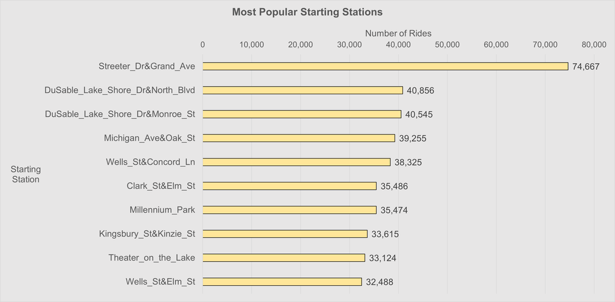

Most Popular Ending Stations

| Station Name | Number of Rides |
| --- | --- |
| Streeter Dr & Grand Ave | 76,186 |
| DuSable Lake Shore Dr & North Blvd | 44,057 |
| Michigan Ave & Oak St | 40,143 |
| DuSable Lake Shore Dr & Monroe St | 39,687 |
| Wells St & Concord Ln | 38,317 |
| Millennium Park | 36,430 |
| Clark St & Elm St | 35,074 |
| Theater on the Lake | 33,548 |
| Kingsbury St & Kinzie St | 32,567 |
| Wells St & Elm St | 31,638 |

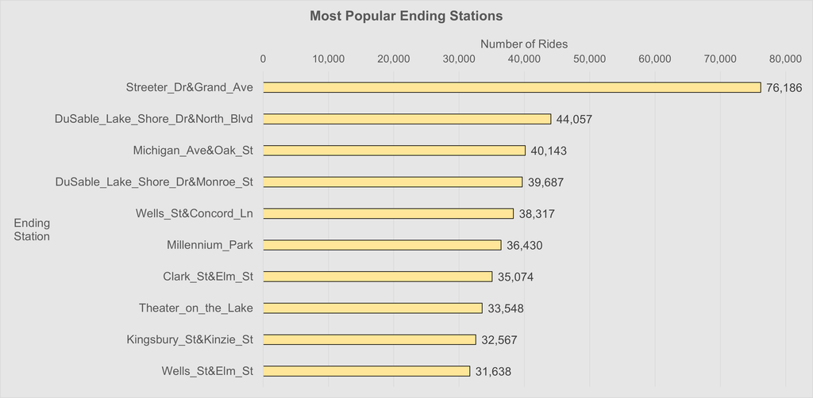

[figure not shown]

Some of the stations such as Streeter Dr & Grand Ave Station, Millennium Park Station, Theater on the Lake Station, DuSable Lake Shore Dr & North Blvd Station and DuSable Lake Shore Dr & Monroe St Station are built near tourist attraction such as Navy Pier or Millenium Park which will attract tourists and locals to ride along the harbour or coastline. In addition to that, there are multiple parks such as Olive Park, DuSable Park around the stations that encourages users to ride around with a bike.

Other stations such as Michigan Ave & Oak St Station, Wells St & Concord Ln Staion, Clark St & Elm Station, Wells St & Elm St Station and Kingsbury St & Kinzie St Station are popular as there are no metro station near these station which encourages the people to move around with a bicycle in addition to the well structured bike lane around the area.

2.Bike Types and Member Types

Riding Length Summary

| Riding Length (seconds) | Member | Casual |
| --- | --- | --- |
| Max | 86,128 | 86,362 |
| Min | 0 | 0 |
| Mean | 752.2 | 1497 |
| Median | 544 | 883 |

Average Ride Length (seconds) By Rider Type

| Weekdays | Member | Casual |
| --- | --- | --- |
| Sunday | 753.48 | 1,511.60 |
| Monday | 749.93 | 1,478.62 |
| Tuesday | 756.26 | 1,518.30 |
| Wednesday | 744.01 | 1,491.54 |
| Thursday | 751.01 | 1,501.01 |
| Friday | 755.38 | 1,473.85 |
| Saturday | 754.90 | 1,501.60 |

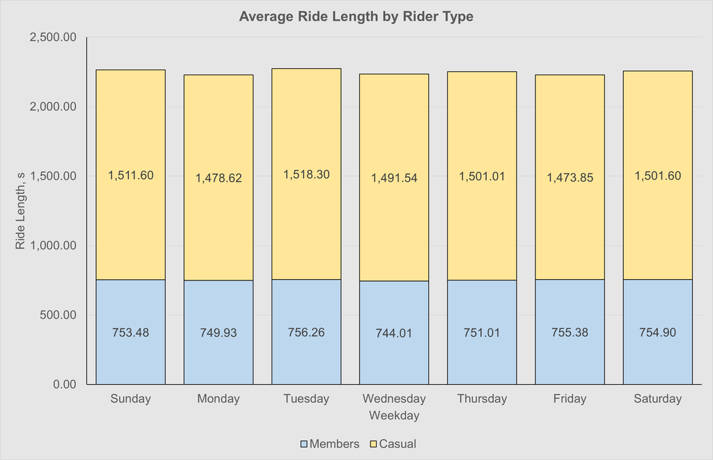

From this summary, it would seem that the average casual riders (around 25 mins) tend to rent the bikes longer than average member riders (around 13 mins). The median shows that most casual riders will rent bikes for around 15 mins while member riders will rent bikes for around 10 mins. With this information, an average casual riders would yield $5 of profit per ride while an average member rider would yield $119 of profit per annum. Besides that, the average ride length for the casual members are almost constant which shows that there are daily users in them.

| Time | Member | Casual | Total |
| --- | --- | --- | --- |
| 12 AM - 12:59 AM | 25,960 | 35,794 | 61,754 |
| 1 AM - 1:59 AM | 15,979 | 23,392 | 39,371 |
| 2 AM - 2:59 AM | 8,695 | 14,243 | 22,938 |
| 3 AM - 3:59 AM | 5,281 | 7,958 | 13,239 |
| 4 AM - 4:59 AM | 6,281 | 5,343 | 11,624 |
| 5 AM - 5:59 AM | 27,871 | 8,902 | 36,773 |
| 6 AM - 6:59 AM | 77,815 | 21,098 | 98,913 |
| 7 AM - 7:59 AM | 146,502 | 38,658 | 185,160 |
| 8 AM - 8:59 AM | 170,687 | 52,786 | 223,473 |
| 9 AM - 9:59 AM | 116,544 | 59,018 | 175,562 |
| 10 AM - 10:59 AM | 108,671 | 79,318 | 187,989 |
| 11 AM - 11:59 AM | 130,651 | 103,921 | 234,572 |
| 12 PM - 12:59 PM | 148,869 | 120,372 | 269,241 |
| 1 PM - 1:59 PM | 145,254 | 125,462 | 270,716 |
| 2 PM - 2:59 PM | 144,306 | 130,692 | 274,998 |
| 3 PM - 3:59 PM | 173,410 | 142,501 | 315,911 |
| 4 PM - 4:59 PM | 235,372 | 158,528 | 393,900 |
| 5 PM - 5:59 PM | 289,099 | 180,414 | 469,513 |
| 6 PM - 6:59 PM | 232,708 | 161,330 | 394,038 |
| 7 PM - 7:59 PM | 164,314 | 122,754 | 287,068 |
| 8 PM - 8:59 PM | 113,347 | 88,816 | 202,163 |
| 9 PM - 9:59 PM | 86,956 | 76,141 | 163,097 |
| 10 PM - 10:59 PM | 65,267 | 69,414 | 134,681 |
| 11 PM - 11:59 PM | 42,272 | 51,098 | 93,370 |

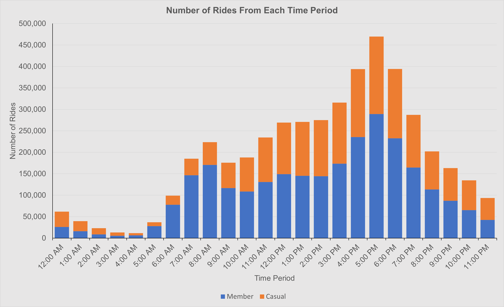

The amount of casual member is around 41.2% (1,877,953) of the overall number of rides which shows that converting them to annual member is a workable solution into increasing the profit of the company. Considering 30% of the total users choose this service to commute to work everyday, it would be better to target this group of people that are currently not an annual member. The majority of the rides at 7 AM and 8 AM are from annual members which shows that they use this service to commute to work or study frequently. The percentage of casual members slowly increases after those period. The peak period of this bicycle service is at the time period around 5 to 6 PM with the most casual members of the day..

Number of Rides Based on Different Bike Types and Member Types

| Bike Type | Member | Casual | Total |
| --- | --- | --- | --- |
| Classic Bike | 1,862,776 | 1,027,997 | 2,890,773 |
| Electric Bike | 819,335 | 644,184 | 1,463,519 |
| Docked Bike | 0 | 205,772 | 205,772 |
| Total | 2,682,111 | 1,877,953 | 4,560,064 |

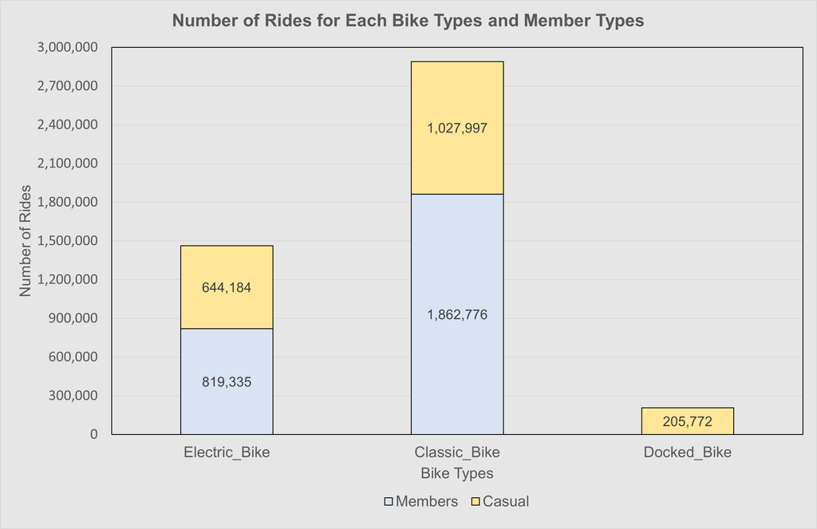

Based on the above figure, docked bikes are not as popular as electric bike and classic bike. This is mainly caused by the limited docking stations available around Chicago. Docked bikes may not even be available during haevy traffic hours. In addition to that, it is not friendly to new cyclists as they are required to search a docking station in unfamiliar places which is better for them to pick a classic bike or an electric bike to move around.

Electric bikes are better than docked bikes since it is easier to ride but it has similar problem to the docking stations which is the charging stations. The users will have to change batteries after it was depleted which requires them to search for its stations. Some users may experience renting a not fully charged electric bike.

As an article posted on Streetsblog Chicago by Courtney Cobbson on May 5 2022, 5 charging stations was set at the following locations, Wilton Avenue and Diversey Parkway, Lincoln Avenue and Roscoe Street, Bissell Street and Armitage Avenue, Green Street and Randolph Street, Morgan Street and Lake Street in order to charge the new e-bikes. This was done to prevent multiple trips to exchange the electric bikes’ battery and to prevent any electric bikes that is not fully charged being rented by people.

[figure not shown]

Casual bikes are the most popular bikes among the three as the docking locations are very flexible, the users can dock their bikes any stations in Chicago and anywhere in the scooter zone for an extra charge of $1 for Divvy members and $2 for non-members.

[figure not shown]

Number of Rides By Member Types and Weekdays

| Weekdays | **Members** | **Casual** |
| --- | --- | --- |
| Sunday | 385,136 | 277,025 |
| Monday | 375,661 | 265,199 |
| Tuesday | 384,807 | 276,347 |
| Wednesday | 375,945 | 250,975 |
| Thursday | 382,494 | 269,832 |
| Friday | 389,530 | 262,272 |
| Saturday | 388,538 | 276,303 |

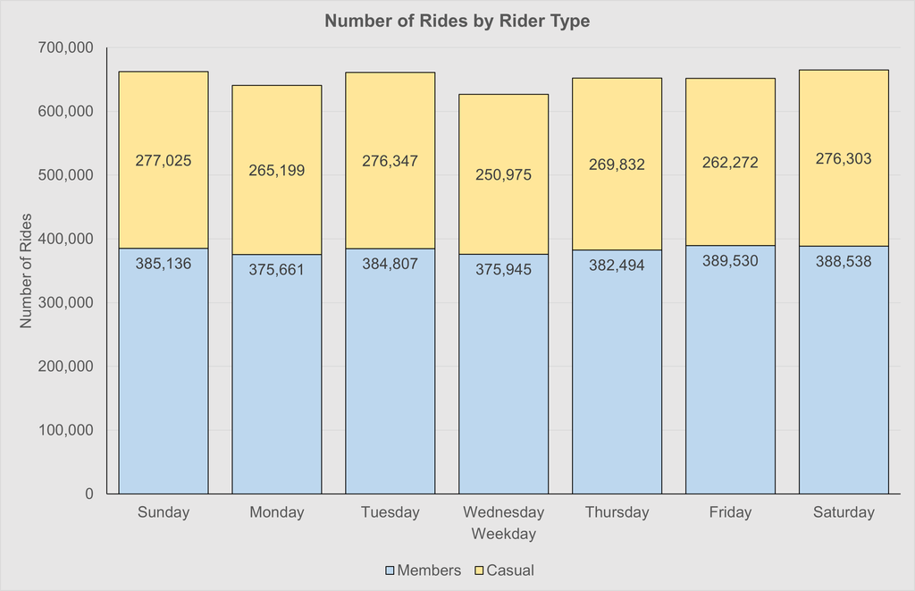

The number of riders shown for every different days are at a stable value, there is no drastic increase or decrease in values for each day. This shows that everyday bike riding is becoming a normal thing to the residents of Chicago. This also shows that these casual riders are similar to the annual riders that they ride bikes everyday for works and as a mean to move around in the city. The slight increase and decrease in riders can represent tourists that visits Chicago while the majority of the riders are locals.

| Months | Member | Casual |
| --- | --- | --- |
| September 2021 | 328,205 | 292,930 |
| October 2021 | 288,855 | 189,117 |
| November 2021 | 185,909 | 69,958 |
| December 2021 | 131,295 | 45,076 |
| January 2022 | 67,523 | 12,605 |
| February 2022 | 74,034 | 15,144 |
| March 2022 | 148,827 | 67,154 |
| April 2022 | 180,663 | 91,897 |
| May 2022 | 282,299 | 220,246 |
| June 2022 | 328,281 | 292,067 |
| July 2022 | 330,996 | 311,670 |
| August 2022 | 335,224 | 270,089 |

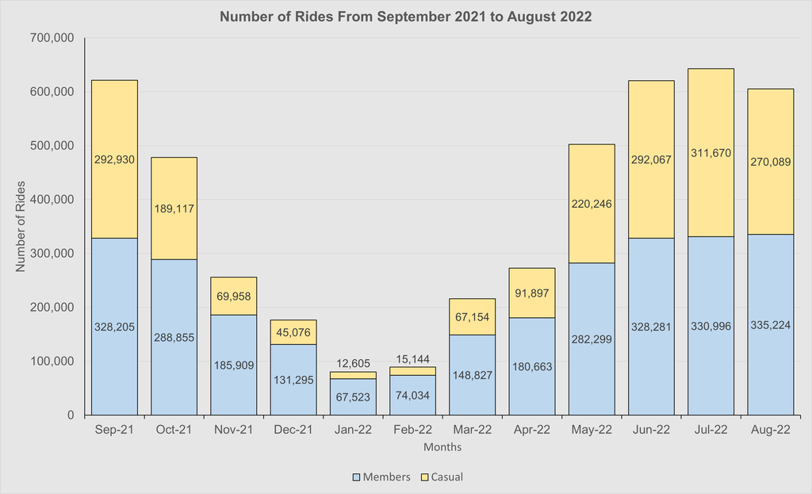

The number of rides for each month is shown in the figure above. The number of rides are at the lowest in January 2022, followed by February 2022 and December 2021. This is due to different seasons that worsen the road condition and the drastic change in temperature which is not suitable for cycling. The following figure shows the temperature change in Fahrenheit for year 2021 and 2022.

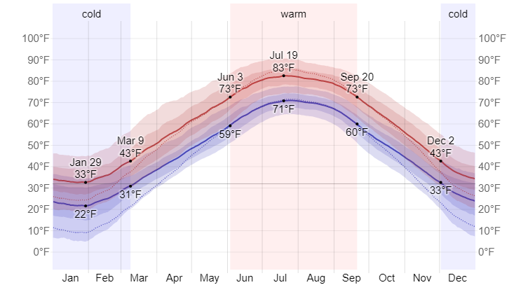

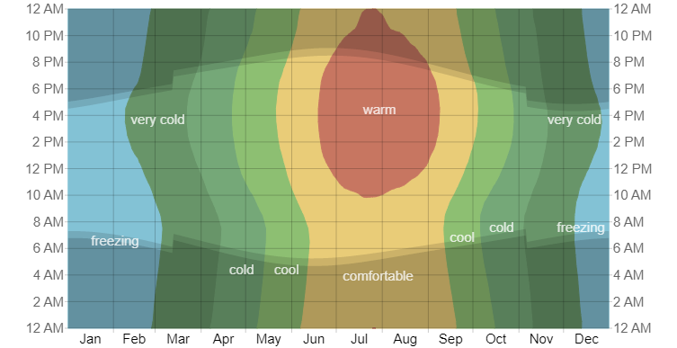

As shown in the figure above, the average temperature at the month of January 2022 is in between 22 Fahrenheit to 33 Fahrenheit. This freezing temperature is not suitable for outdoor activity. So, the only users that are using this service at this month would be annual members for the purpose of travelling to work or study. This results in the low number of casual members because of the low temperature. In between June and September, the average temperature is suitable for outdoor activity which attracts tourists to come which is shown by the increase of casual members in number starting from May 2022.

## **Solution**

1.Increase the cost per minute for the single-ride pass by $0.02

The reason for this approach is to make the users think that applying the annual membership is a better decision. Even if they think otherwise, the increased price of the single-ride pass is still profitable to the company. By taking the average duration for a casual rider in the analysis section, the profit will increase from $5 to $5.5.

2.Improve the advertisement for E-bike service

The price for the E-bike service for annual member is the same as renting a casual bike as a casual member which is $1 + $0.16 / minute. They would consider to be a good deal when the comparison is made clear to them.

3.Consider helmet renting service

A helmet is a must to ride a bike for safety reason but it is not convenient to carry around a helmet when not riding a bike. With this service, people would feel more accessible to use this bike renting service especially when there is an emergency. It would be a plus if there is a small discount when the helmet is returned to the stations to prevent any loss helmet. An easier way to prevent helmet went lost is to pair each bike with their own helmets to track records.